# Time_series_analysis

## **1. When to use Time Series Analysis?**

Time Series Analysis is used for continuous data and for the data which is auto-correlated. Autocorrelation means the value in a single column is related to it's previous value. It is generally used for a data which appears to have a date column (continuous value) & y (dependent col) which is autocorrelated. Having said that Time Series Analysis has only y(dependent variable) & no x (independent variables). So using this algorithm we will forecast the values of y by analysing the patterns in the data.

## **2. Types of Time Series Analysis?**

Time Series Analysis can be further categorized into 2 types:

```
1. Exponential Smoothening
    a. Simple exponential smoothening
    b. Double exponential smoothening
    c. Triple exponential smoothening

2. ARIMA (Autoregressive Integrated Moving Average.)
```

## **3. Requirements for Time Series Analysis**

The major requirement for the Time series analysis is to first make sure that the data has a unified gaping. It should be either in daily, weekly or monthly format for the whole data. To give an example, Time series cannot be applied if we have weekly and monthly data together.

## **4. How should the Time series data look like before preprocessing?**

In Time series analysis we have a Date column which we consider as an index column, in addition to it we have one more column 'y' (e.g. Sales, Profit,...). In a scenario, where the data given to us has multiple columns we have to make sure we only keep the y and date column, dropping all other columns.

# Code

### **Problem statement: Forecast the Sales for 1 year of Furniture products category on the basis of historical data of the superstore.**

### **1. Importing the Libraries & Reading the data.**

```python
# Importing the Libraries & Reading the data
import pandas as pd
import numpy as np
import matplotlib.pyplot as plt
```

```python
df = pd.read_excel(r"Sample_Superstore.xls",header = 0)
```

```python
df.head()
```

|  | Row ID | Order ID | Order Date | Ship Date | Ship Mode | Customer ID | Customer Name | Segment | Country | City | ... | Postal Code | Region | Product ID | Category | Sub-Category | Product Name | Sales | Quantity | Discount | Profit |
| --- | --- | --- | --- | --- | --- | --- | --- | --- | --- | --- | --- | --- | --- | --- | --- | --- | --- | --- | --- | --- | --- |
| 0 | 1 | CA-2016-152156 | 2016-11-08 | 2016-11-11 | Second Class | CG-12520 | Claire Gute | Consumer | United States | Henderson | ... | 42420 | South | FUR-BO-10001798 | Furniture | Bookcases | Bush Somerset Collection Bookcase | 261.9600 | 2 | 0.00 | 41.9136 |
| 1 | 2 | CA-2016-152156 | 2016-11-08 | 2016-11-11 | Second Class | CG-12520 | Claire Gute | Consumer | United States | Henderson | ... | 42420 | South | FUR-CH-10000454 | Furniture | Chairs | Hon Deluxe Fabric Upholstered Stacking Chairs,... | 731.9400 | 3 | 0.00 | 219.5820 |
| 2 | 3 | CA-2016-138688 | 2016-06-12 | 2016-06-16 | Second Class | DV-13045 | Darrin Van Huff | Corporate | United States | Los Angeles | ... | 90036 | West | OFF-LA-10000240 | Office Supplies | Labels | Self-Adhesive Address Labels for Typewriters b... | 14.6200 | 2 | 0.00 | 6.8714 |
| 3 | 4 | US-2015-108966 | 2015-10-11 | 2015-10-18 | Standard Class | SO-20335 | Sean O'Donnell | Consumer | United States | Fort Lauderdale | ... | 33311 | South | FUR-TA-10000577 | Furniture | Tables | Bretford CR4500 Series Slim Rectangular Table | 957.5775 | 5 | 0.45 | -383.0310 |
| 4 | 5 | US-2015-108966 | 2015-10-11 | 2015-10-18 | Standard Class | SO-20335 | Sean O'Donnell | Consumer | United States | Fort Lauderdale | ... | 33311 | South | OFF-ST-10000760 | Office Supplies | Storage | Eldon Fold 'N Roll Cart System | 22.3680 | 2 | 0.20 | 2.5164 |

5 rows × 21 columns

```python
# Checking the dimensions
df.shape
```

```
(9994, 21)
```

```python
# Let us check total categories.
df['Category'].value_counts()
```

```
Category
Office Supplies    6026
Furniture          2121
Technology         1847
Name: count, dtype: int64
```

### **2. Making a subset of data for Category 'Furniture'**

Now since we are only concerned about forecasting Category as Furniture, we make a subset of original data 'df' by filtering only the Category which has furniture in it.

```python
# Now making a subset of df for Category 'furniture' and storing Category as Furniture in it.
furniture = df[df['Category']=='Furniture']
furniture.shape
```

```
(2121, 21)
```

```python
furniture.dtypes
```

```
Row ID                    int64
Order ID                 object
Order Date       datetime64[ns]
Ship Date        datetime64[ns]
Ship Mode                object
Customer ID              object
Customer Name            object
Segment                  object
Country                  object
City                     object
State                    object
Postal Code               int64
Region                   object
Product ID               object
Category                 object
Sub-Category             object
Product Name             object
Sales                   float64
Quantity                  int64
Discount                float64
Profit                  float64
dtype: object
```

Now once filtered, if we check the data type (dtypes) we get to see the Date column has the data type as datetime:If in case it doesn't then one can apply the following transformation using pandas to convert it into Date format.

```python
# In case the column is not present in datetime format, one can convert it as follows:
furniture['Order Date']=pd.to_datetime(furniture['Order Date'])
```

However, since in the above data we have the Order Date column already in Date format, we don't need to apply this transformation.

```python
# Checking minimum & maximum value for Order date
furniture['Order Date'].min(),furniture['Order Date'].max()
```

```
(Timestamp('2014-01-06 00:00:00'), Timestamp('2017-12-30 00:00:00'))
```

### **3. Keeping only the relevant columns (Order Date, Sales)**

Now since we want only the Sales and Order Date as columns we modify furniture to keep just these 2 columns

```python
furniture = furniture[['Order Date','Sales']]
furniture.shape
```

```
(2121, 2)
```

```python
furniture
```

|  | Order Date | Sales |
| --- | --- | --- |
| 0 | 2016-11-08 | 261.9600 |
| 1 | 2016-11-08 | 731.9400 |
| 3 | 2015-10-11 | 957.5775 |
| 5 | 2014-06-09 | 48.8600 |
| 10 | 2014-06-09 | 1706.1840 |
| ... | ... | ... |
| 9962 | 2015-03-19 | 383.4656 |
| 9964 | 2016-12-05 | 13.4000 |
| 9980 | 2015-09-06 | 85.9800 |
| 9989 | 2014-01-21 | 25.2480 |
| 9990 | 2017-02-26 | 91.9600 |

2121 rows × 2 columns

### **4.Sorting the Date column in ascending order**

We sort the date column in ascending order and check for null values.

```python
furniture = furniture.sort_values('Order Date', ascending=True)
furniture.isnull().sum()
```

```
Order Date    0
Sales         0
dtype: int64
```

```python
furniture.head(10)
```

|  | Order Date | Sales |
| --- | --- | --- |
| 7474 | 2014-01-06 | 2573.820 |
| 7660 | 2014-01-07 | 76.728 |
| 866 | 2014-01-10 | 51.940 |
| 716 | 2014-01-11 | 9.940 |
| 2978 | 2014-01-13 | 545.940 |
| 4938 | 2014-01-13 | 333.999 |
| 6474 | 2014-01-14 | 61.960 |
| 970 | 2014-01-16 | 127.104 |
| 5465 | 2014-01-19 | 181.470 |
| 6327 | 2014-01-20 | 272.940 |

### **5. Grouping the Date column to avoid multiple entries**

Let us first check the value count for Order date

```python
furniture['Order Date'].value_counts
```

```
<bound method IndexOpsMixin.value_counts of 7474   2014-01-06
7660   2014-01-07
866    2014-01-10
716    2014-01-11
2978   2014-01-13
          ...
7636   2017-12-29
7632   2017-12-29
5131   2017-12-29
7635   2017-12-29
906    2017-12-30
Name: Order Date, Length: 2121, dtype: datetime64[ns]>
```

To avoid using multiple entries we can make use of 'Group by' function. 'Group by' function will aggregate all the entries of Order Date to give a summarized result. In the code below we are grouping the furniture column on Order Date and aggregating it over Sum of Sales.

```python
furniture = furniture.groupby('Order Date')['Sales'].sum().reset_index()
furniture.shape
```

```
(889, 2)
```

### **6. Setting Date column as an Index**

Since we want to forecast on just the Sales column we are setting Date column as an Index

```python
# Set Order Date as Index, so that we have just one column Sales.
furniture = furniture.set_index('Order Date')
```

```python
furniture.head(10)
```

| Order Date | Sales |
| --- | --- |
| 2014-01-06 | 2573.820 |
| 2014-01-07 | 76.728 |
| 2014-01-10 | 51.940 |
| 2014-01-11 | 9.940 |
| 2014-01-13 | 879.939 |
| 2014-01-14 | 61.960 |
| 2014-01-16 | 127.104 |
| 2014-01-19 | 181.470 |
| 2014-01-20 | 1413.510 |
| 2014-01-21 | 25.248 |

### **7. Resampling the data**

We resample the data to avoid inconsistencies. To give an example for a superstore, on Saturday and Sunday the store would be close so for those dates we would not have any entry for Sales which would eventually lead to Gapping. Time Series analysis cannot be applied if the data has Gapping within it. This can be however resolved by Resampling the data. In this case we are resampling the data over Month (hence 'M') and filling the inconsistencies using mean of the monthly Sales.

```python
 y= furniture['Sales'].resample('M').mean()
```

```python
y
```

```
Order Date
2014-01-31     480.194231
2014-02-28     367.931600
2014-03-31     857.291529
2014-04-30     567.488357
2014-05-31     432.049188
2014-06-30     695.059242
2014-07-31     601.169500
2014-08-31     457.521656
2014-09-30     992.353367
2014-10-31     769.015437
2014-11-30     980.221486
2014-12-31    1532.298325
2015-01-31     978.328467
2015-02-28     522.395667
2015-03-31     781.236437
2015-04-30     805.822962
2015-05-31     624.996700
2015-06-30     428.565500
2015-07-31     719.706316
2015-08-31     602.412012
2015-09-30    1382.790684
2015-10-31     632.980184
2015-11-30    1286.701354
2015-12-31    1049.355418
2016-01-31     508.182867
2016-02-29     356.868273
2016-03-31     609.575810
2016-04-30     695.373158
2016-05-31     687.265227
2016-06-30     816.910750
2016-07-31     768.736412
2016-08-31     734.307782
2016-09-30    1135.953371
2016-10-31     624.872474
2016-11-30    1271.345152
2016-12-31    1410.719808
2017-01-31     397.602133
2017-02-28     528.179800
2017-03-31     544.672240
2017-04-30     453.297905
2017-05-31     678.302328
2017-06-30     826.460291
2017-07-31     562.524857
2017-08-31     857.881889
2017-09-30    1209.508583
2017-10-31     875.362728
2017-11-30    1277.817759
2017-12-31    1256.298672
Freq: M, Name: Sales, dtype: float64
```

```python
print(y.shape)
```

```
(48,)
```

### **8. Plotting the graph for 'y'**

We plot a line graph for 'y' using matplotlib, to see how it looks like

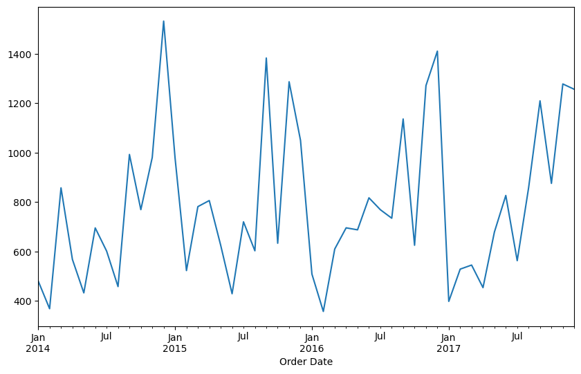

```python
y.plot(figsize=(10,6))
plt.show()
```

As one can see the plot is a continuous line chart that span over months. The X-axis here is the 'Order Date' and Y-axis here is the 'Sales'.

### **9. Splitting the 'y' data into train & test data**

It is time to split the y data into Train & test. We have kept all the values before '2016-12-31' as Train data & all the values after '2017-01-31' as Testing data. Loc is used to locate the index position for the Date specified.

```python
train = y.loc[ :'2016-12-31']
print(train.shape)
train
```

```
(36,)
```

```
Order Date
2014-01-31     480.194231
2014-02-28     367.931600
2014-03-31     857.291529
2014-04-30     567.488357
2014-05-31     432.049188
2014-06-30     695.059242
2014-07-31     601.169500
2014-08-31     457.521656
2014-09-30     992.353367
2014-10-31     769.015437
2014-11-30     980.221486
2014-12-31    1532.298325
2015-01-31     978.328467
2015-02-28     522.395667
2015-03-31     781.236437
2015-04-30     805.822962
2015-05-31     624.996700
2015-06-30     428.565500
2015-07-31     719.706316
2015-08-31     602.412012
2015-09-30    1382.790684
2015-10-31     632.980184
2015-11-30    1286.701354
2015-12-31    1049.355418
2016-01-31     508.182867
2016-02-29     356.868273
2016-03-31     609.575810
2016-04-30     695.373158
2016-05-31     687.265227
2016-06-30     816.910750
2016-07-31     768.736412
2016-08-31     734.307782
2016-09-30    1135.953371
2016-10-31     624.872474
2016-11-30    1271.345152
2016-12-31    1410.719808
Freq: M, Name: Sales, dtype: float64
```

```python
test = y.loc['2017-01-31':]
print(test.shape)
test
```

```
(12,)
```

```
Order Date
2017-01-31     397.602133
2017-02-28     528.179800
2017-03-31     544.672240
2017-04-30     453.297905
2017-05-31     678.302328
2017-06-30     826.460291
2017-07-31     562.524857
2017-08-31     857.881889
2017-09-30    1209.508583
2017-10-31     875.362728
2017-11-30    1277.817759
2017-12-31    1256.298672
Freq: M, Name: Sales, dtype: float64
```

### **10. Plotting the train & test data**

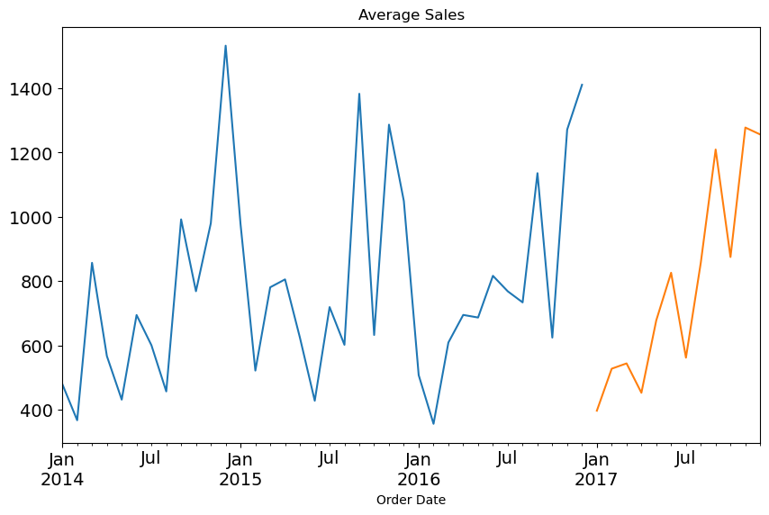

```python
train.plot(figsize=(10,6),title='Average Sales',fontsize = 14)
test.plot(figsize=(10,6),title='Average Sales',fontsize = 14)
plt.show()
```

The above figure clearly shows the divison of train & test data. The Train data is represented with blue line & the Test data is represented using orange line.

In Time series analysis we have two important concepts 'Seasonality' and 'Trend'. Trend for any time series data can be either upward or downward, whereas Seasonality will tell the behaviour of data for a particular season (For e.g. Wedding season, Monsoon season, Festivals and so on). To analyse these patterns, an algorithm called Exponential Smoothing has been developed. Exponential Smoothing is categorised into 3 types:

a. Simple Exponential Smoothing

b. Double Exponential Smoothing

c. Triple Exponential Smoothing

Let us understand each smoothening type one by one.

## **11. Exponential Smoothing**

Exponential Smoothing is based on 3 hyperparameters: Alpha (smoothing level:importance to Old values), Beta (smoothing slope:Trend) & Gamma (seasonal period: Seasonality).. Let us try to understand how these parameters influence the smoothing.

### **11.1 Single Exponential Smoothing**

If we have 3 years of data and say if we need to forecast the future 'y' for this data, then it is but natural that the recent values from the past will have more importance in forecasting the future values rather than the values that are 1/2/3 years old.

Alpha is such a hyperparameter which decides how much importance we are giving to the old values. If alpha is close to 0, then the new values are given more importance and if it is close to 1, then the old values are given more importance.

**Single Exponential Smoothing is the algorithm that deals with only alpha.** In Single Exponential Smoothing we do not look for Trend (beta) or Seasonality (gamma).

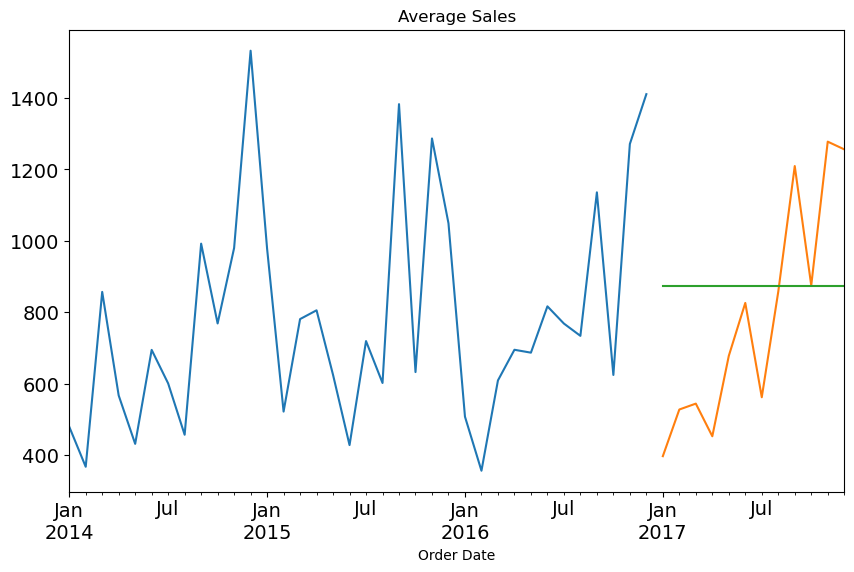

```python
from statsmodels.tsa.api import SimpleExpSmoothing
Exp_Smooth = test.copy()

# smoothing level = alpha
# alpha value should be in the range of 0 to 1
# values close to 0 indicate that older values are very less compared to the recent values.
# values close to 1 indicate that older values are equally important.

fit1 = SimpleExpSmoothing(train).fit(smoothing_level = 0.1)
Exp_Smooth['SES'] = fit1.forecast(steps=len(test))

train.plot(figsize=(10,6),title='Average Sales',fontsize = 14)
test.plot(figsize=(10,6),title='Average Sales',fontsize = 14)
Exp_Smooth['SES'].plot(figsize=(10,6),title='Average Sales',fontsize = 14)
plt.show()
```

Do not forget to first install statsmodels library in the anaconda prompt using pip install statsmodels. To explain the code above, here we have imported SimpleExpSmoothing function from stats model library. We have named a variable 'Exp_Smooth' and saved a copy of test data in it. Furthermore, we train the model for alpha (smoothing level = 0.1) and fit it later on test data. We use Exp_Smooth['SES'] to forecast, here SES stands for Simple Exponential Smoothing. Lastly we plot the graphs for test, train and Exp_Smooth['SES'].

The line Exp_Smooth['SES'] (green colour) is a line that just forecasts the future sales. This line however is a straight line and not completely accurate since we have not added the hyperparameter of Beta(smoothing slope: trend) & Gamma (seasonal period:Seasonality).

```python
# Checking RMSE for Single Exponential model.

from sklearn.metrics import mean_squared_error
from math import sqrt
rmse = sqrt(mean_squared_error(test,Exp_Smooth.SES))
print(rmse)
```

```
315.0328571018992
```

### **11.2 Double Exponential Smoothing (Holt model)**

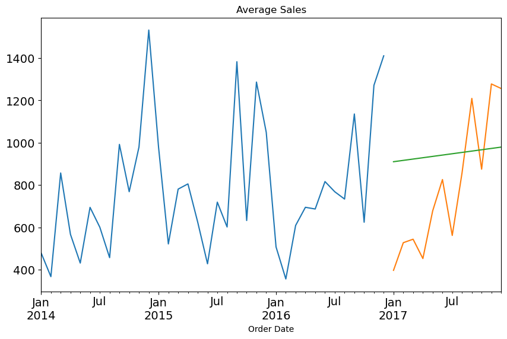

```python
# Holt model
from statsmodels.tsa.api import Holt
Holt_df = test.copy()

# smoothing level = beta
# aplha value should be in the range of 0 to 1
# values close to 0 indicate that older values are very less compared to the recent values.
# values close to 1 indicate that older values are equally important.

fit1 = Holt(train).fit(smoothing_level = 0.1,smoothing_slope = 0.25)
Holt_df['Holt_linear'] = fit1.forecast(steps=len(test))

train.plot(figsize=(10,6),title='Average Sales',fontsize = 14)
test.plot(figsize=(10,6),title='Average Sales',fontsize = 14)
Holt_df['Holt_linear'].plot(figsize=(10,6),title='Average Sales',fontsize = 14)
plt.show()
```

```python
# Checking RMSE for Holt model

from sklearn.metrics import mean_squared_error
from math import sqrt
rmse = sqrt(mean_squared_error(test,Holt_df['Holt_linear']))
print(rmse)
```

```
324.2370497814364
```

### **11.3 Triple Exponential Smoothing (Holt Winter model)**

This is a bit more advanced and efficient algorithm since it performs exponential smoothing on all the 3 hyperparameters. **In addition to smoothing line and smoothing slope we introduce another hyperparameter called seasonal period.** A seasonal period= 12 indicates 12 months.The code will be the same again, this time however instead of specifying the values we are adding the trend and we have defined seasonal periods as 12. The data will be fitted on train model and forecasted using the fit on test and stored as 'Holt_Winter_df'.

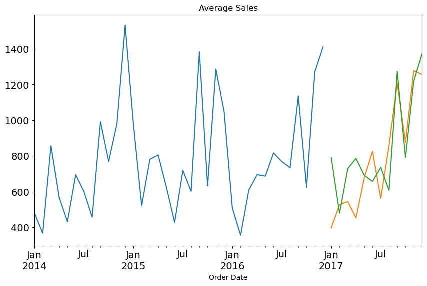

```python
# Holt Winter model
from statsmodels.tsa.api import ExponentialSmoothing
Holt_Winter_df = test.copy()

# smoothing level = beta
# aplha value should be in the range of 0 to 1
# values close to 0 indicate that older values are very less compared to the recent values.
# values close to 1 indicate that older values are equally important.

fit1 = ExponentialSmoothing(train,seasonal_periods = 12, trend = 'add', seasonal = 'add').fit()
Holt_Winter_df['Holt_linear'] = fit1.forecast(steps=len(test))

train.plot(figsize=(10,6),title='Average Sales',fontsize = 14)
test.plot(figsize=(10,6),title='Average Sales',fontsize = 14)
Holt_Winter_df['Holt_linear'].plot(figsize=(10,6),title='Average Sales',fontsize = 14)
plt.show()
```

If one observes the green graph (Holt_Winter_df['Holt_linear']), one can infer that Triple Exponential Smoothing seems to be by far the best smoothing algorithm that forecasts the data more accurately. This can be also confirmed by comparing the RMSE value of each Smoothing algorithm.

```python
# Checking RMSE for Holt Winter model.

from sklearn.metrics import mean_squared_error
from math import sqrt
rmse = sqrt(mean_squared_error(test,Holt_Winter_df['Holt_linear']))
print(rmse)
```

```
193.71177930414166
```

# Applying Holt_Winter on office supplies data. (optional)

## We have to repeat all the steps right from Preprocessing till evaluation of rmse.

```python
# Let us check total categories.
df['Category'].value_counts()
```

```
Category
Office Supplies    6026
Furniture          2121
Technology         1847
Name: count, dtype: int64
```

```python
Office_Supplies = df[df['Category']=='Office Supplies']
Office_Supplies.shape
```

```
(6026, 21)
```

```python
Office_Supplies.dtypes
```

```
Row ID                    int64
Order ID                 object
Order Date       datetime64[ns]
Ship Date        datetime64[ns]
Ship Mode                object
Customer ID              object
Customer Name            object
Segment                  object
Country                  object
City                     object
State                    object
Postal Code               int64
Region                   object
Product ID               object
Category                 object
Sub-Category             object
Product Name             object
Sales                   float64
Quantity                  int64
Discount                float64
Profit                  float64
dtype: object
```

```python
Office_Supplies['Order Date']=pd.to_datetime(Office_Supplies['Order Date'])
```

```python
Office_Supplies = Office_Supplies[['Order Date','Sales']]
Office_Supplies.shape
```

```
(6026, 2)
```

```python
Office_Supplies
```

|  | Order Date | Sales |
| --- | --- | --- |
| 2 | 2016-06-12 | 14.620 |
| 4 | 2015-10-11 | 22.368 |
| 6 | 2014-06-09 | 7.280 |
| 8 | 2014-06-09 | 18.504 |
| 9 | 2014-06-09 | 114.900 |
| ... | ... | ... |
| 9982 | 2016-09-22 | 35.560 |
| 9984 | 2015-05-17 | 31.500 |
| 9985 | 2015-05-17 | 55.600 |
| 9992 | 2017-02-26 | 29.600 |
| 9993 | 2017-05-04 | 243.160 |

6026 rows × 2 columns

```python
Office_Supplies = Office_Supplies.sort_values('Order Date', ascending=True)
Office_Supplies.isnull().sum()
```

```
Order Date    0
Sales         0
dtype: int64
```

```python
Office_Supplies.head(10)
```

|  | Order Date | Sales |
| --- | --- | --- |
| 7980 | 2014-01-03 | 16.448 |
| 740 | 2014-01-04 | 272.736 |
| 739 | 2014-01-04 | 11.784 |
| 741 | 2014-01-04 | 3.540 |
| 1759 | 2014-01-05 | 19.536 |
| 5327 | 2014-01-06 | 19.440 |
| 7180 | 2014-01-06 | 12.780 |
| 7475 | 2014-01-06 | 609.980 |
| 7480 | 2014-01-06 | 6.540 |
| 7479 | 2014-01-06 | 31.120 |

```python
Office_Supplies['Order Date'].value_counts
```

```
<bound method IndexOpsMixin.value_counts of 7980   2014-01-03
740    2014-01-04
739    2014-01-04
741    2014-01-04
1759   2014-01-05
          ...
5091   2017-12-30
1297   2017-12-30
908    2017-12-30
1296   2017-12-30
645    2017-12-30
Name: Order Date, Length: 6026, dtype: datetime64[ns]>
```

```python
Office_Supplies = Office_Supplies.groupby('Order Date')['Sales'].sum().reset_index()
Office_Supplies.shape
```

```
(1148, 2)
```

```python
# Set Furniture as Index, so that we have just one column Sales.
Office_Supplies = Office_Supplies.set_index('Order Date')
```

```python
Office_Supplies.head(10)
```

| Order Date | Sales |
| --- | --- |
| 2014-01-03 | 16.448 |
| 2014-01-04 | 288.060 |
| 2014-01-05 | 19.536 |
| 2014-01-06 | 685.340 |
| 2014-01-07 | 10.430 |
| 2014-01-09 | 9.344 |
| 2014-01-10 | 2.890 |
| 2014-01-13 | 2027.116 |
| 2014-01-16 | 48.660 |
| 2014-01-18 | 64.864 |

```python
 y= Office_Supplies['Sales'].resample('M').mean()
```

```python
print(y.shape)
```

```
(48,)
```

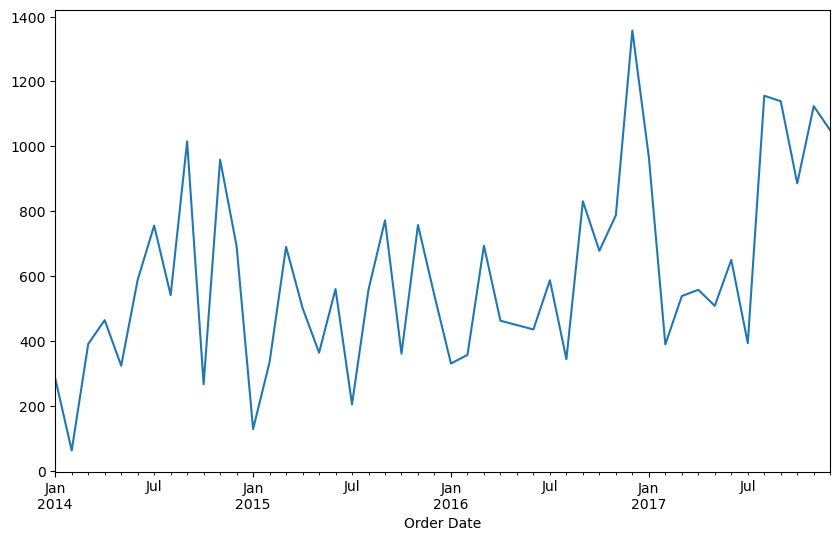

```python
y.plot(figsize=(10,6))
plt.show()
```

```python
train = y.loc[ :'2016-12-31']
print(train.shape)
train
```

```
(36,)
```

```
Order Date
2014-01-31     285.357647
2014-02-28      63.042588
2014-03-31     391.176318
2014-04-30     464.794750
2014-05-31     324.346545
2014-06-30     588.774409
2014-07-31     756.060400
2014-08-31     541.879143
2014-09-30    1015.677704
2014-10-31     267.078815
2014-11-30     959.372714
2014-12-31     692.556231
2015-01-31     129.198571
2015-02-28     335.504188
2015-03-31     690.545522
2015-04-30     502.342320
2015-05-31     364.549440
2015-06-30     560.407737
2015-07-31     205.214739
2015-08-31     558.814667
2015-09-30     772.230680
2015-10-31     361.392083
2015-11-30     757.790357
2015-12-31     540.055800
2016-01-31     331.230125
2016-02-29     357.597368
2016-03-31     693.877240
2016-04-30     462.932478
2016-05-31     449.489724
2016-06-30     436.072400
2016-07-31     587.474727
2016-08-31     344.605385
2016-09-30     830.847786
2016-10-31     678.408083
2016-11-30     787.972231
2016-12-31    1357.055929
Freq: M, Name: Sales, dtype: float64
```

```python
test = y.loc['2017-01-31':]
print(test.shape)
test
```

```
(12,)
```

```
Order Date
2017-01-31     967.013136
2017-02-28     389.882737
2017-03-31     538.899481
2017-04-30     558.229296
2017-05-31     508.776444
2017-06-30     650.463038
2017-07-31     393.902615
2017-08-31    1156.148154
2017-09-30    1139.137250
2017-10-31     886.045846
2017-11-30    1124.012036
2017-12-31    1049.549724
Freq: M, Name: Sales, dtype: float64
```

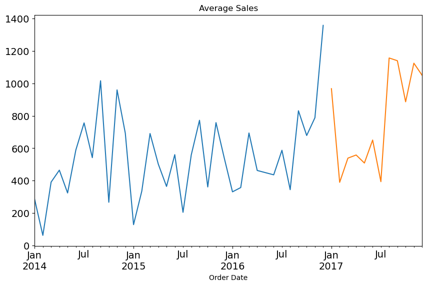

```python
train.plot(figsize=(10,6),title='Average Sales',fontsize = 14)
test.plot(figsize=(10,6),title='Average Sales',fontsize = 14)
plt.show()
```

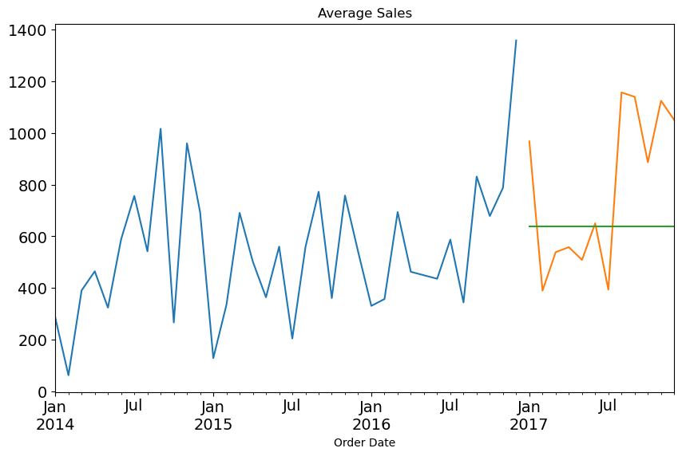

```python
from statsmodels.tsa.api import SimpleExpSmoothing
Exp_Smooth = test.copy()

# smoothing level = alpha
# alpha value should be in the range of 0 to 1
# values close to 0 indicate that older values are very less compared to the recent values.
# values close to 1 indicate that older values are equally important.

fit1 = SimpleExpSmoothing(train).fit(smoothing_level = 0.1)
Exp_Smooth['SES'] = fit1.forecast(steps=len(test))

train.plot(figsize=(10,6),title='Average Sales',fontsize = 14)
test.plot(figsize=(10,6),title='Average Sales',fontsize = 14)
Exp_Smooth['SES'].plot(figsize=(10,6),title='Average Sales',fontsize = 14)
plt.show()
```

```python
from sklearn.metrics import mean_squared_error
from math import sqrt
rmse = sqrt(mean_squared_error(test,Exp_Smooth.SES))
print(rmse)
```

```
322.64286904085685
```

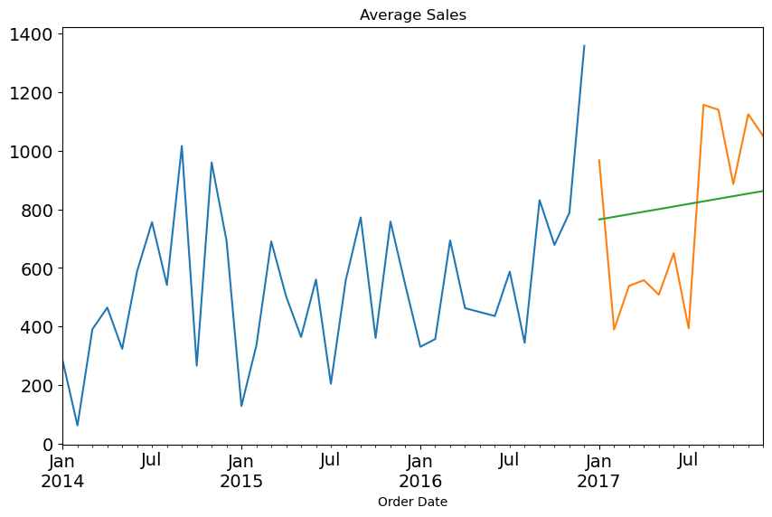

```python
# Holt model
from statsmodels.tsa.api import Holt
Holt_df = test.copy()

# smoothing level = beta
# aplha value should be in the range of 0 to 1
# values close to 0 indicate that older values are very less compared to the recent values.
# values close to 1 indicate that older values are equally important.

fit1 = Holt(train).fit(smoothing_level = 0.1,smoothing_slope = 0.25)
Holt_df['Holt_linear'] = fit1.forecast(steps=len(test))

train.plot(figsize=(10,6),title='Average Sales',fontsize = 14)
test.plot(figsize=(10,6),title='Average Sales',fontsize = 14)
Holt_df['Holt_linear'].plot(figsize=(10,6),title='Average Sales',fontsize = 14)
plt.show()
```

```python
from sklearn.metrics import mean_squared_error
from math import sqrt
rmse = sqrt(mean_squared_error(test,Holt_df['Holt_linear']))
print(rmse)
```

```
274.32638791662873
```

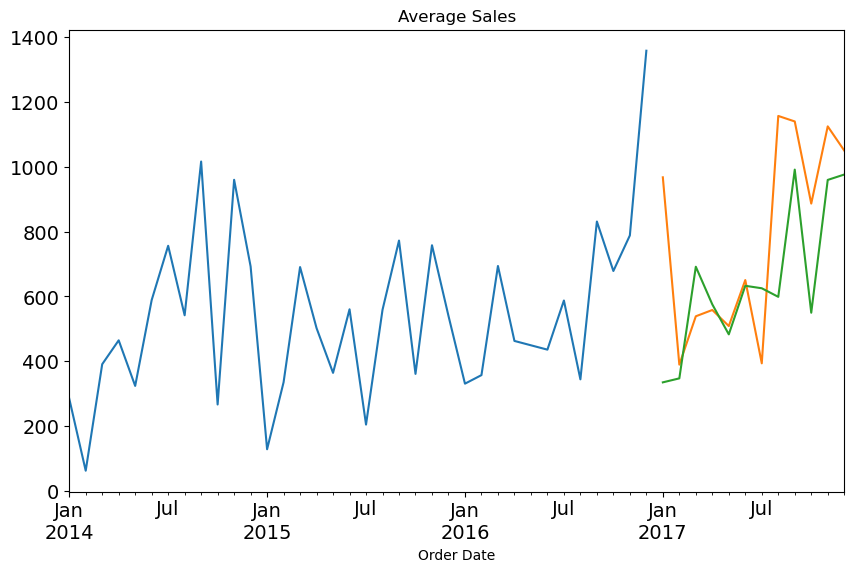

```python
# Holt Winter model
from statsmodels.tsa.api import ExponentialSmoothing
Holt_Winter_df = test.copy()

# smoothing level = beta
# aplha value should be in the range of 0 to 1
# values close to 0 indicate that older values are very less compared to the recent values.
# values close to 1 indicate that older values are equally important.

fit1 = ExponentialSmoothing(train,seasonal_periods = 12, trend = 'add', seasonal = 'add').fit()
Holt_Winter_df['Holt_linear'] = fit1.forecast(steps=len(test))

train.plot(figsize=(10,6),title='Average Sales',fontsize = 14)
test.plot(figsize=(10,6),title='Average Sales',fontsize = 14)
Holt_Winter_df['Holt_linear'].plot(figsize=(10,6),title='Average Sales',fontsize = 14)
plt.show()
```

```python
from sklearn.metrics import mean_squared_error
from math import sqrt
rmse = sqrt(mean_squared_error(test,Holt_Winter_df['Holt_linear']))
print(rmse)
```

```
282.4468093413045
```

So the RMSE for office Supplies Category is '282.44' which is a good value.

## **12. ARIMA (Autoregressive Integrated Moving Average)**

### **12.1 ARIMA concept**

Exponential Smoothening generally works where the **volatility or fluctuations** in the data is not much. However, if we have volatile data **(say for example Stock market data, cryptocurreny data)** then simple exponential smoothening won't perform well. In such scenarios we use ARIMA (Autoregressive Integrated Moving Average).

An ARIMA model is a class of statistical models for analyzing and forecasting time series data.

• **AR:** Autoregression. A model that uses the dependent relationship between an observation and some number of lagged observations.

• **I:** Integrated. The use of differencing of raw observations (e.g. subtracting an observation from an observation at the previous time step) in order to make the time series stationary.

• **MA:** Moving Average. A model that uses the dependency between an observation and a residual error from a moving average model applied to lagged observations.

### **12.2 Parameters in ARIMA**

The parameters of the ARIMA model are defined as follows:

• **p:** The number of lag observations included in the model, also called the lag order.

• **d:** The number of times that the raw observations are differenced, also called the degree of differencing.

• **q:** The size of the moving average window, also called the order of moving average. If a Time Series has seasonal patterns, we have to insert seasonal periods, and it becomes SARIMA, short for 'Seasonal ARIMA'.

Just like Exponential Smoothening where we had (alpha, beta & gamma), here as well by adjusting 'p', 'd' , 'q' values we can adjust the accuracy of the model.

Let us first install the package for pmdarima to get started.

```python
! pip install pmdarima
```

### **12.3 Importing the library pmdarima**

```python
import pmdarima as pm
```

### **12.4 Applying Auto_arima on y & fetching p,d, & q values**

The ARIMA model is an Autoregressive model which means it will optimise the values of 'p', 'd' & 'q' after analysing the data to give us an accurate forecast.

```python
model = pm.auto_arima(y, start_p = 0,max_p= 3, d=None, max_d = 2, start_q=0, max_q=3,
                      start_P =0, max_P = 3, D= None, max_D = 2, start_Q = 0, max_Q = 3,
                       max_order= 10, m= 12, seasonal = True, information_criterion = 'aic',
                        test='adf', trace = True, random_state = 10 )
```

```
Performing stepwise search to minimize aic
 ARIMA(0,1,0)(0,0,0)[12] intercept   : AIC=682.234, Time=0.05 sec
 ARIMA(1,1,0)(1,0,0)[12] intercept   : AIC=672.340, Time=0.25 sec
 ARIMA(0,1,1)(0,0,1)[12] intercept   : AIC=inf, Time=0.17 sec
 ARIMA(0,1,0)(0,0,0)[12]             : AIC=680.349, Time=0.02 sec
 ARIMA(1,1,0)(0,0,0)[12] intercept   : AIC=673.518, Time=0.06 sec
 ARIMA(1,1,0)(2,0,0)[12] intercept   : AIC=671.706, Time=0.33 sec
 ARIMA(1,1,0)(3,0,0)[12] intercept   : AIC=673.094, Time=1.00 sec
 ARIMA(1,1,0)(2,0,1)[12] intercept   : AIC=673.093, Time=0.78 sec
 ARIMA(1,1,0)(1,0,1)[12] intercept   : AIC=inf, Time=0.44 sec
 ARIMA(1,1,0)(3,0,1)[12] intercept   : AIC=inf, Time=1.47 sec
 ARIMA(0,1,0)(2,0,0)[12] intercept   : AIC=679.178, Time=0.21 sec
 ARIMA(2,1,0)(2,0,0)[12] intercept   : AIC=667.310, Time=0.66 sec
 ARIMA(2,1,0)(1,0,0)[12] intercept   : AIC=667.427, Time=0.17 sec
 ARIMA(2,1,0)(3,0,0)[12] intercept   : AIC=669.160, Time=2.55 sec
 ARIMA(2,1,0)(2,0,1)[12] intercept   : AIC=669.167, Time=1.03 sec
 ARIMA(2,1,0)(1,0,1)[12] intercept   : AIC=inf, Time=0.48 sec
 ARIMA(2,1,0)(3,0,1)[12] intercept   : AIC=inf, Time=0.98 sec
 ARIMA(3,1,0)(2,0,0)[12] intercept   : AIC=669.306, Time=0.75 sec
 ARIMA(2,1,1)(2,0,0)[12] intercept   : AIC=669.300, Time=0.94 sec
 ARIMA(1,1,1)(2,0,0)[12] intercept   : AIC=inf, Time=0.72 sec
 ARIMA(3,1,1)(2,0,0)[12] intercept   : AIC=inf, Time=0.87 sec
 ARIMA(2,1,0)(2,0,0)[12]             : AIC=665.610, Time=0.31 sec
 ARIMA(2,1,0)(1,0,0)[12]             : AIC=665.850, Time=0.11 sec
 ARIMA(2,1,0)(3,0,0)[12]             : AIC=667.430, Time=0.71 sec
 ARIMA(2,1,0)(2,0,1)[12]             : AIC=667.431, Time=0.67 sec
 ARIMA(2,1,0)(1,0,1)[12]             : AIC=inf, Time=0.41 sec
 ARIMA(2,1,0)(3,0,1)[12]             : AIC=inf, Time=1.75 sec
 ARIMA(1,1,0)(2,0,0)[12]             : AIC=669.803, Time=0.24 sec
 ARIMA(3,1,0)(2,0,0)[12]             : AIC=667.609, Time=0.41 sec
 ARIMA(2,1,1)(2,0,0)[12]             : AIC=667.608, Time=0.47 sec
 ARIMA(1,1,1)(2,0,0)[12]             : AIC=662.845, Time=0.45 sec
 ARIMA(1,1,1)(1,0,0)[12]             : AIC=663.716, Time=0.17 sec
 ARIMA(1,1,1)(3,0,0)[12]             : AIC=664.340, Time=0.94 sec
 ARIMA(1,1,1)(2,0,1)[12]             : AIC=664.352, Time=0.73 sec
 ARIMA(1,1,1)(1,0,1)[12]             : AIC=inf, Time=0.44 sec
 ARIMA(1,1,1)(3,0,1)[12]             : AIC=inf, Time=4.53 sec
 ARIMA(0,1,1)(2,0,0)[12]             : AIC=661.855, Time=0.33 sec
 ARIMA(0,1,1)(1,0,0)[12]             : AIC=662.183, Time=0.11 sec
 ARIMA(0,1,1)(3,0,0)[12]             : AIC=663.207, Time=0.75 sec
 ARIMA(0,1,1)(2,0,1)[12]             : AIC=663.212, Time=0.64 sec
 ARIMA(0,1,1)(1,0,1)[12]             : AIC=inf, Time=0.36 sec
 ARIMA(0,1,1)(3,0,1)[12]             : AIC=inf, Time=2.08 sec
 ARIMA(0,1,0)(2,0,0)[12]             : AIC=677.202, Time=0.16 sec
 ARIMA(0,1,2)(2,0,0)[12]             : AIC=662.944, Time=0.39 sec
 ARIMA(1,1,2)(2,0,0)[12]             : AIC=664.625, Time=0.88 sec
 ARIMA(0,1,1)(2,0,0)[12] intercept   : AIC=inf, Time=0.53 sec

Best model:  ARIMA(0,1,1)(2,0,0)[12]
Total fit time: 32.573 seconds
```

In the code block above I am applying auto arima on 'y' data (It is the same data we splitted during Exp Smoothening). Here, we have to keep the code default without changing any parameters. The output of this code will get us the p,d,q values. In the output 'Best model : ARIMA (0,1,1)', p=0, d = 1, q=1 are the values obtained.

### **12.5 Fitting the model on SARIMAX.**

SARIMAX is a function which is used when we want to fit seasonal data. Since the data is seasonal data related to Sales we are importing 'SARIMAX' function on which we go ahead and fit the model. We have already confirmed the presence of Seasonality from the Holt_Winter model. Important thing to note here is that we are using'p','d' & 'q' values obtained from auto_arima to fit the model. To get started, let us intsall the required statsmodels library package.

```python
! pip install statsmodels
```

```python
from statsmodels.tsa.statespace.sarimax import SARIMAX

model = SARIMAX(train,order=(0,1,1),seasonal_order=(2,0,0,12)).fit()
```

In the code above, I am applying SARIMAX function from statsmodels library and fitting the data on the 'p','d','q' values obtained above where p=0, d=1, q=1. Since we imported SARIMAX we have to specify (2,0,0) which we obtained after auto_arima followed by seasonal periods = 12 and then fit the model.

As mentioned earlier, auto_arima will itself decide the p,d, q values which then help us in fitting the model as shown above.

### **12.6 Predicting the model using forecast function.**

[figure not shown]

```python
#pred = model.get_prediction(start-pd.to_datetime('2017-01-31'))

pred = model.get_forecast(steps=12)
ax = y['2014':].plot(label="observed")
pred.predicted_mean.plot(ax=ax, label= "Validation Forecast")
ax.set_xlabel('Date')
ax.set_ylabel('Furniture Sales')
plt.legend()
plt.show()
```

In the code above we are generating a forecast using the get_forecast() method on the fitted model. The steps=12 argument indicates that the forecast should be for 12 time steps into the future. We are then storing this forecast in a variable named 'pred'.

Once stored then we are using data from 'y' to make a plot of observed data. The ['2014':] slicing notation is used to select data from the year 2014 onwards. The label="observed" in the argument specifies the label for this data series in the plot.

pred.predicted_mean.plot() plots the forecasted values stored in pred on the same plot as the observed data (ax). pred.predicted_mean retrieves the predicted mean values from the forecast object pred, and .plot(ax=ax) plots these values on the same plot as the observed data. The label="Validation Forecast" argument specifies the label for predicted mean values of the forecast.

**In simple words we are comparing 2 plots: one is the plot of 'y' 2014 onwards (named as ax:observed) & the second is the predicted mean plot of the forecasted values stored in pred for ax (named as pred.predicted_mean(ax): Validation Forecast)**

**Always remember, predicted mean of forecasted values will give us the 'Forecast'. So the above graph in simple words is a graph comparing actual vs forecasted values.**

Let us see what were the predicted mean values for the forecast.**This predicted mean is nothing but our 'Y_pred'**.

```python
pred.predicted_mean
```

```
2017-01-31    408.638250
2017-02-28    487.020914
2017-03-31    710.612542
2017-04-30    576.024578
2017-05-31    524.943173
2017-06-30    587.632978
2017-07-31    512.688492
2017-08-31    559.200650
2017-09-30    780.227940
2017-10-31    593.665967
2017-11-30    762.231135
2017-12-31    861.510146
Freq: M, Name: predicted_mean, dtype: float64
```

### **12.7 Evaluation of the ARIMA model using rmse.**

Now we are defining our Y_pred & Y_test first, where Y_pred as mentioned is the predicted mean of the forecasted values. Y_test is the value of 'y' for 2017-01-31 onwards. We are then evaluating rmse (root mean squared error) on Y_test & Y_pred. RMSE will give us the actual difference between the Test & Forecasted values.

```python
Y_pred = pred.predicted_mean
Y_test = y['2017-01-31':]

from sklearn.metrics import mean_squared_error
from math import sqrt

rmse = sqrt(mean_squared_error(Y_test,Y_pred))
print(rmse)
```

```
303.6214696836191
```

### **12.8 Evaluation of the ARIMA model using rmse on the entire 'y' data.**

The evaluation we did above was on the model that was fitted on the train data of 'y'. Now let us the ARIMA model for the entire 'y' data and compare the RMSE values. To do this, follow the same steps starting from:

```python
from statsmodels.tsa.statespace.sarimax import SARIMAX

model = SARIMAX(y,order=(0,1,1),seasonal_order=(2,0,0,12)).fit()
```

[figure not shown]

```python
#pred = model.get_prediction(start-pd.to_datetime('2017-01-31'))

pred = model.get_forecast(steps=12)
ax = y['2014':].plot(label="observed")
pred.predicted_mean.plot(ax=ax, label= "Validation Forecast")
ax.set_xlabel('Date')
ax.set_ylabel('Furniture Sales')
plt.legend()
plt.show()
```

```python
pred.predicted_mean
```

```
2018-01-31     888.699730
2018-02-28     741.912688
2018-03-31     884.354843
2018-04-30     819.169779
2018-05-31     801.807427
2018-06-30     835.728000
2018-07-31     813.036309
2018-08-31     943.512733
2018-09-30    1087.110853
2018-10-31     972.766962
2018-11-30    1069.988872
2018-12-31    1223.417370
Freq: M, Name: predicted_mean, dtype: float64
```

```python
Y_pred = pred.predicted_mean
Y_test = y['2017-01-31':]

from sklearn.metrics import mean_squared_error
from math import sqrt

rmse = sqrt(mean_squared_error(Y_test,Y_pred))
print(rmse)
```

```
241.85745016017432
```

### **12.9 Exporting the results as an excel file.**

```python
pred.predicted_mean.to_excel("Timeseriesoutput.xlsx", index=True)
```